# Evaluation of Food Trends using Yelp dataset

Lik Sin  
9/11/15

Food trends come and go, it is important for restaurants to be keenly aware of the latest whims and fancies of their customers.

We analysed review data from Yelp dataset to provide insights on food trends and what mattered most to diners.

### Methods

1. Load Yelp dataset and preprocess data
2. Mine text from restaurant reviews
3. Rank keywords by frequencies of words each year
4. Generate linear model for each word (Predictor=year, Outcome=Rank)
5. Sort words according to P-value of linear model
6. Analyse results

### Results

1. Assumption: Words with high frequency mattered most to reviewers
2. Higher importance => Higher frequency => Higher rank
3. Linear model shows trend over time
4. Positive slope = increasing importance
5. Negative slope = decreasing importance
6. Low P-value = high probability of large change over time
7. High P-value = high probability no change over time

### Results - Words with large change in importance (low P-values)

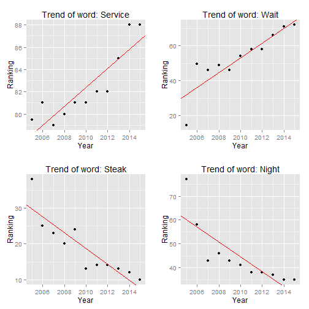

Low P-value words

- Positive slope: “service”, “chicken”, “wait”
- Negative slope: “steak”, “night”

### Results - Words with consistent importance over time (high P-values)

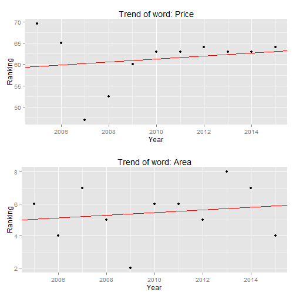

High P-value words

- High rank: “price”, “pizza”
- Low rank: “area”, “salad”